# Basic Least Squares

David Asare Kumi

June 20, 2019

## Introduction: Basic Least Squares

- Let’s look at the data first used by Francis Galton in 1885.
- Galton was a statistician who invented the term and concepts of regression and correlation, founded the journal Biometrika, and was the cousin of Charles Darwin.

```r
library(ggplot2)
library(HistData)
data(Galton)
head(Galton)
```

```
##   parent child
## 1   70.5  61.7
## 2   68.5  61.7
## 3   65.5  61.7
## 4   64.5  61.7
## 5   64.0  61.7
## 6   67.5  62.2
```

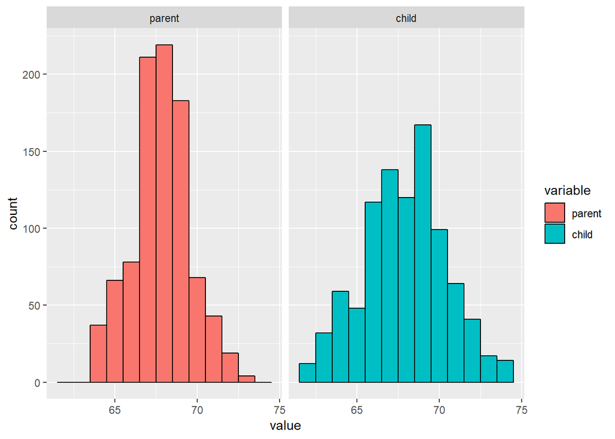

```r
library(reshape)
long <-melt(Galton)
g <-ggplot(long,aes(x=value,fill=variable))
g <-g+geom_histogram(color="black",binwidth=1)
g <-g+facet_grid(.~variable)
g
```

## Introductory Data

### Example

- comparing children’s heights and their parent’s heights.

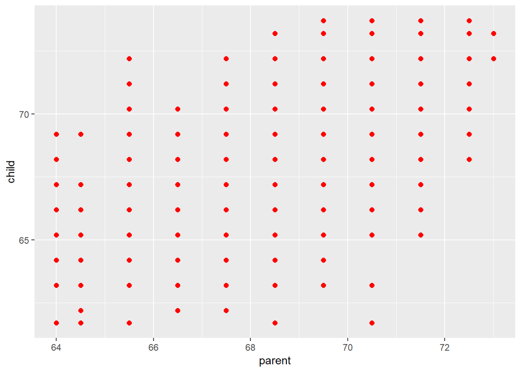

```r
library(HistData)
library(ggplot2)
data(Galton)
g <-ggplot(Galton,aes(x=parent,y=child))+geom_point(color="red",size=2,alpha=1)
g
```

## Least Squares Estimation of Regression Lines

- Least squaress minimizes the error sum of squares.

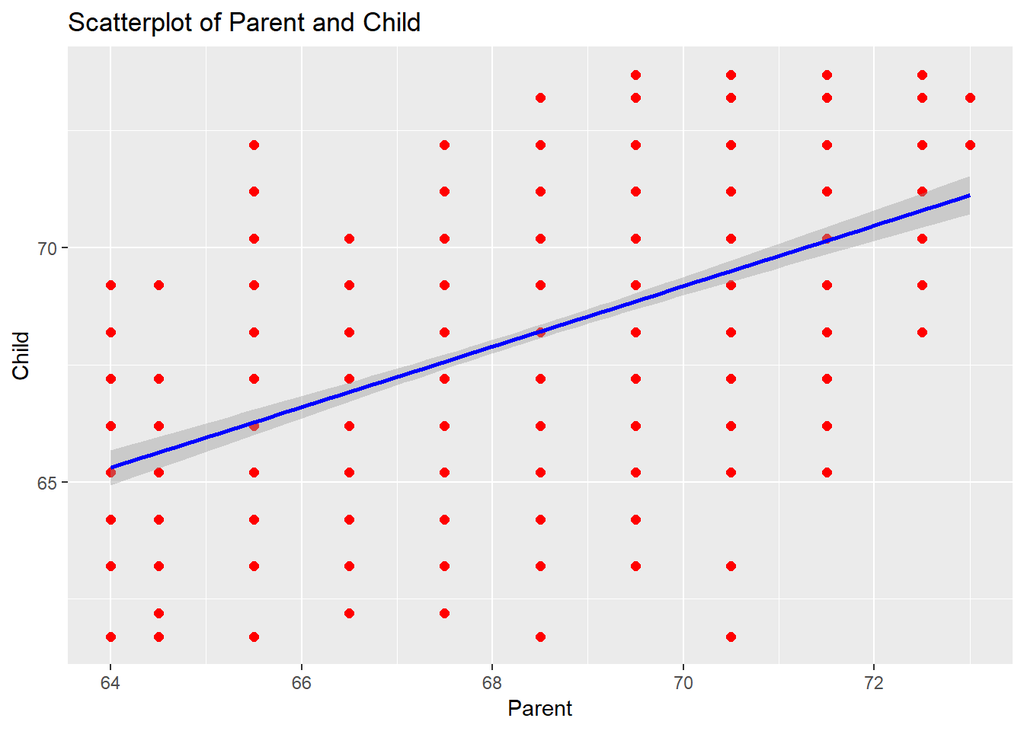

```r
library(HistData)
library(ggplot2)
data(Galton)
x <-Galton$parent
y <-Galton$child
g <-ggplot(Galton,aes(x,y))+geom_point(color="red",size=2,alph=1)+geom_smooth(method="lm",size=1,
    color="blue")+labs(x="Parent",y="Child")+labs(title="Scatterplot of Parent and Child")
g
```

```r
#Fitting the best line
fit <-lm(y~x,data=Galton)
summary(fit)$coef
```

```
##               Estimate Std. Error   t value     Pr(>|t|)
## (Intercept) 23.9415302 2.81087834  8.517455 6.536845e-17
## x            0.6462906 0.04113588 15.711115 1.732509e-49
```

```r
#Fitting the best line (alternative approach)
slope <-cor(y,x)*sd(y)/sd(x)
slope
```

```
## [1] 0.6462906
```

```r
intercept <-mean(y)-slope*mean(x)
intercept
```

```
## [1] 23.94153
```

```r
#The slope of the regression line with X as the outcome and y as the predictor
slope1 <-cor(y,x)*sd(x)/sd(y)
slope1
```

```
## [1] 0.3256475
```

```r
intercept1 <-mean(x)-slope1*mean(y)
intercept1
```

```
## [1] 46.13535
```

```r
#correlation y,x = correlation x,y
cor(y,x)
```

```
## [1] 0.4587624
```

```r
cor(x,y)
```

```
## [1] 0.4587624
```

- Regression to the origin yielded the same slope as a linear regression which does not necessarily have zero(0) intercept if you mean centered the y’s and you mean centered the x’s.

```r
library(HistData)
library(ggplot2)
data(Galton)
x <-Galton$parent
y <-Galton$child
yc <-y-mean(y) #y centered
xc <-x-mean(x) #x centered
beta1 <-sum(yc*xc)/sum(xc^2)
beta1
```

```
## [1] 0.6462906
```

```r
#Alternatively
c(beta1,coef(lm(y~x))[2]) #[2] grabs the second coefficient i.e. the slope
```

```
##                   x
## 0.6462906 0.6462906
```

```r
c(beta1,coef(lm(y~x))[1]) #[1] grabs the intercept i.e. the constant term
```

```
##             (Intercept)
##   0.6462906  23.9415302
```

```r
c(coef(lm(y~x))[1],coef(lm(y~x))[2]) # grabs the intercept and the slope
```

```
## (Intercept)           x
##  23.9415302   0.6462906
```

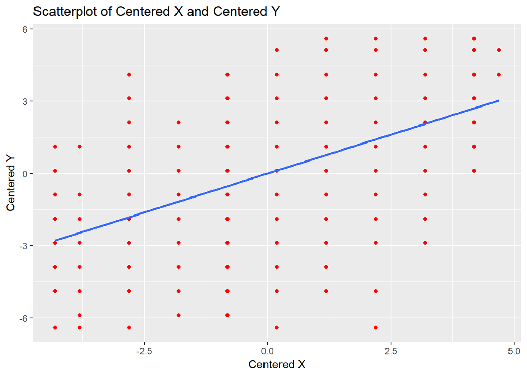

```r
#Plot
g <-ggplot(Galton,aes(xc,yc))+geom_point(color="red",alpha=1)+geom_smooth(method="lm",se=FALSE)+labs(x="Centered X",y="Centered Y")+labs(title="Scatterplot of Centered X and Centered Y")
g
```

```r
#Regression to the origin using lm (get rid of the intercept)
lm(yc~xc-1) #-1 takes the intercept out
```

```
##
## Call:
## lm(formula = yc ~ xc - 1)
##
## Coefficients:
##     xc
## 0.6463
```

## Normalizing variables results in the slope being the correlaiton

```r
library(HistData)
library(ggplot2)
data(Galton)
x <-Galton$parent
y <-Galton$child
yn <-(y-mean(y))/sd(y)
xn <-(x-mean(x))/sd(x)
#concatenate
c(cor(y,x),cor(yn,xn),coef(lm(yn~xn))[2])
```

```
##                            xn
## 0.4587624 0.4587624 0.4587624
```

```r
sd(yn)
```

```
## [1] 1
```

```r
sd(xn)
```

```
## [1] 1
```

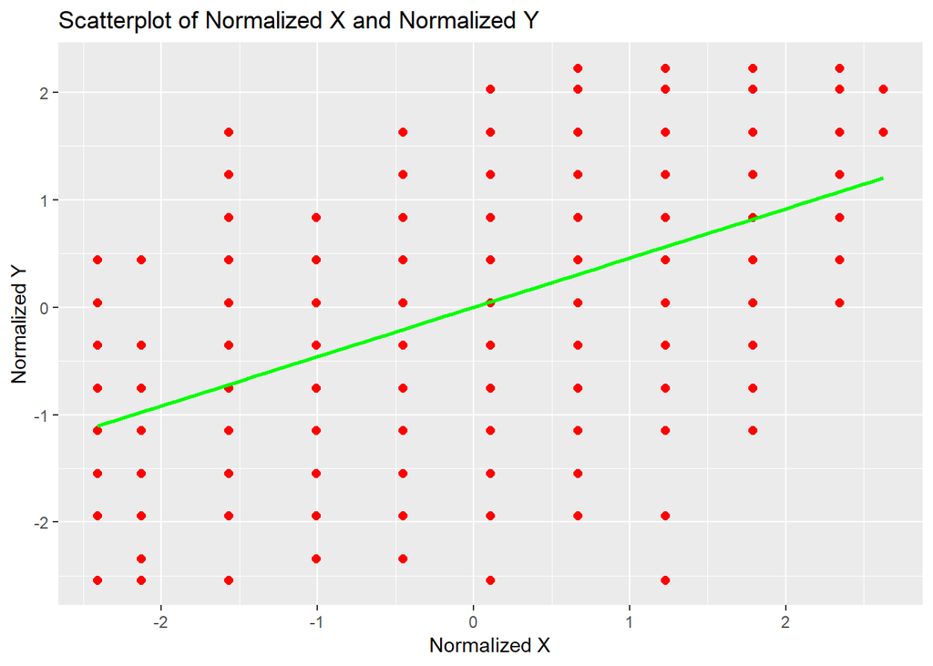

```r
#Plot
g <-ggplot(Galton,aes(xn,yn))+geom_point(color="red",size=2,alpha=1)+geom_smooth(method="lm",se=FALSE,color="green")+labs(x="Normalized X",y="Normalized Y")+labs(title="Scatterplot of Normalized X and Normalized Y")
g
```

## Regression to the Mean

```r
library(MASS)
library(HistData)
library(ggplot2)
library(lattice)
library(Hmisc)
library(backports)
library(htmlTable)
library(UsingR)
data(father.son)
dim(father.son)
```

```
## [1] 1078    2
```

```r
names(father.son)
```

```
## [1] "fheight" "sheight"
```

```r
summary(father.son)
```

```
##     fheight         sheight
##  Min.   :59.01   Min.   :58.51
##  1st Qu.:65.79   1st Qu.:66.93
##  Median :67.77   Median :68.62
##  Mean   :67.69   Mean   :68.68
##  3rd Qu.:69.60   3rd Qu.:70.47
##  Max.   :75.43   Max.   :78.36
```

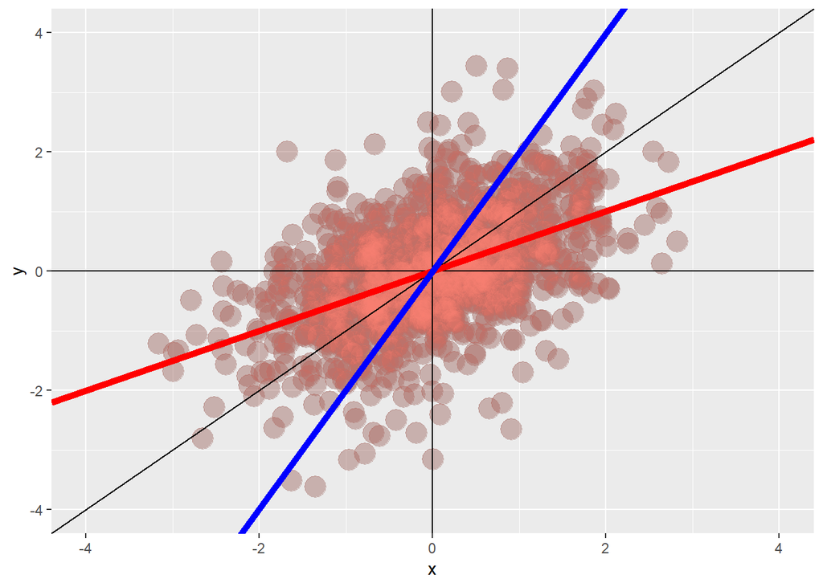

```r
y <-(father.son$sheight-mean(father.son$sheight))/sd(father.son$sheight)
x <-(father.son$fheight-mean(father.son$fheight))/sd(father.son$fheight)
rho <-cor(x,y)
g <-ggplot(data.frame(x=x,y=y),aes(x=x,y=y))
g <-g + geom_point(size=6,color="black",alpha=0.2)
g <-g + geom_point(size=6,color="salmon",alpha=0.2)
g <-g + xlim(-4,4) + ylim(-4,4)
g <-g +geom_abline(intercept=0,slope=1)
g <-g + geom_vline(xintercept=0)
g <-g + geom_hline(yintercept=0)
g <-g + geom_abline(intercept=0,slope=rho,size=2,color="red")
g <-g + geom_abline(intercept=0,slope=1/rho,size=2,color="blue")
g
```

```r
#Regression to the mean is important for longitudinal data.
```

## Linear Regression and Multivariable Regression

### Basic regression model with additive gaussian errors

- Least squares is an estimation too, how do we do inference?
- Consider developing a probabilistic model for linear regression Yi=Bo + B1Xi + Ei.
- Here the Ei are assumed independent and identically distributed (iid) N(0,variance).
- Note, E(Yi/Xi=xi)=mean=Bo+B1Xi.
- Note, Var(Yi/Xi=xi)=variance.
- It is important to note that;
1. Yi is known as the dependent, response, outcome or the regressand variable.
2. Xi is known as the independent, predictor, explanatory or the regressor variable.
3. Bo is a population parameter to estimate and it is known as the intercept or constant term.
4. B1 is a population parameter to estimate and it is known as the slope or the gradient term.

## Interpreting regression coefficients

- Bo is the intercept and it is the expected value of the response variable when the predictor is 0.
- B1 is the slope and it is the expected change in response for a 1 unit change in the predictor.

## Linear Regression for Prediction

- When you plug in the x value you will get the predicted value for y.
- The x value must be within the range of x values in the data (interpolation).
- Extrapolation; predicting outside the range of x values given.

## Example

```r
library(HistData)
library(reshape)
library(Hmisc)
library(backports)
library(htmlTable)
library(ggplot2)
library(UsingR)
data(diamond)
dim(data)
```

```r
str(diamond)
```

```
## 'data.frame':    48 obs. of  2 variables:
##  $ carat: num  0.17 0.16 0.17 0.18 0.25 0.16 0.15 0.19 0.21 0.15 ...
##  $ price: int  355 328 350 325 642 342 322 485 483 323 ...
```

```r
summary(diamond)
```

```
##      carat            price
##  Min.   :0.1200   Min.   : 223.0
##  1st Qu.:0.1600   1st Qu.: 337.5
##  Median :0.1800   Median : 428.5
##  Mean   :0.2042   Mean   : 500.1
##  3rd Qu.:0.2500   3rd Qu.: 657.0
##  Max.   :0.3500   Max.   :1086.0
```

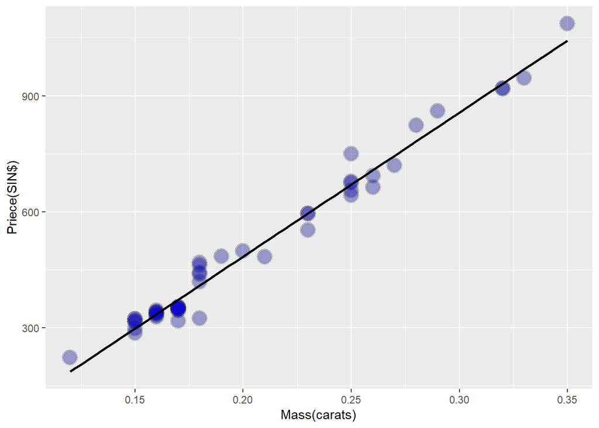

```r
g <-ggplot(diamond,aes(x=carat,y=price))
g <-g + xlab("Mass(carats)")
g <-g + ylab("Priece(SIN$)")
g <-g + geom_point(size=6,color="black",alpha=0.2)
g <-g + geom_point(size=5,color="blue",alpha=0.2)
g <-g + geom_smooth(method="lm",color="black",se=FALSE)
g
```

```r
#Fitting the linear regression model.
fit <-lm(price~carat,data=diamond)
fit
```

```
##
## Call:
## lm(formula = price ~ carat, data = diamond)
##
## Coefficients:
## (Intercept)        carat
##      -259.6       3721.0
```

```r
coef(fit)
```

```
## (Intercept)       carat
##   -259.6259   3721.0249
```

```r
summary(fit)$coef
```

```
##              Estimate Std. Error   t value     Pr(>|t|)
## (Intercept) -259.6259   17.31886 -14.99094 2.523271e-19
## carat       3721.0249   81.78588  45.49715 6.751260e-40
```

```r
summary(fit)
```

```
##
## Call:
## lm(formula = price ~ carat, data = diamond)
##
## Residuals:
##     Min      1Q  Median      3Q     Max
## -85.159 -21.448  -0.869  18.972  79.370
##
## Coefficients:
##             Estimate Std. Error t value Pr(>|t|)
## (Intercept)  -259.63      17.32  -14.99   <2e-16 ***
## carat        3721.02      81.79   45.50   <2e-16 ***
## ---
## Signif. codes:  0 '***' 0.001 '**' 0.01 '*' 0.05 '.' 0.1 ' ' 1
##
## Residual standard error: 31.84 on 46 degrees of freedom
## Multiple R-squared:  0.9783, Adjusted R-squared:  0.9778
## F-statistic:  2070 on 1 and 46 DF,  p-value: < 2.2e-16
```

### Interpretation of the coefficients

- Price = -259.63 + 3721.02Carat
1. Slope; we estimate an expected 3721.02(SIN) dollar increase in price for every carat increase in mass of diamond.
2. The intercept -259.63 is the expected price of a zero(0) carat diamond.

### Getting a more interpretable intercept

```r
#mean center the predictor variable
fit2 <-lm(price~I(carat-mean(carat)),data=diamond)
coef(fit2)
```

```
##            (Intercept) I(carat - mean(carat))
##               500.0833              3721.0249
```

```r
#I function helps us do arithmetic operations inside equations in lm.
```

### Revised interpretation of the intercept

- Price = 500.08 + 3721.02Carat
1. $500.08 is the expected price for the average sized diamond of the data (0.2042 carats).
2. The slope remains the same but the intercept changes to 500.08.

## Predicting the Price of a diamond

```r
newx <-c(0.16,0.27,0.34)
coef(fit)[1]+coef(fit)[2]*newx
```

```
## [1]  335.7381  745.0508 1005.5225
```

```r
#General method
predict(fit,newdata=data.frame(carat=newx))
```

```
##         1         2         3
##  335.7381  745.0508 1005.5225
```

## Residuals

- Unexplained variations by our model.Residuals are the observable errors from the estimated coefficients.In a sense, the residuals are estimates of the errors.
- Errors; unobservable true errors from the known coefficients.
- SSR; sum of squares due to regression - this measures the variation in the fitted values.
- SSE; sum of squares due to error - this measures the discrepancy between the observed and the fitted values.
- SST; sum of squares due to total - this measures the variation in the observed values.

## Residuals and Residual Variations

### Motivating Example

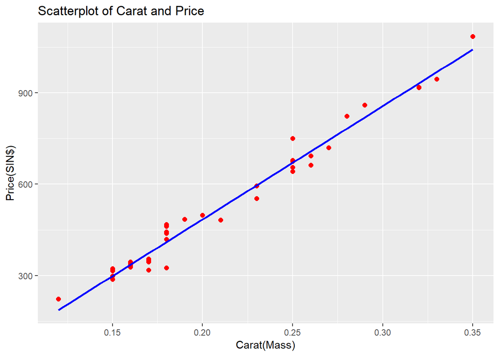

```r
library(HistData)
library(reshape)
library(Hmisc)
library(backports)
library(htmlTable)
library(ggplot2)
library(UsingR)
data(diamond)
g <-ggplot(diamond,aes(x=carat,y=price))
g <-g + geom_point(size=2,color="red",alpha=1) + geom_smooth(method="lm",color="blue",se=FALSE)
g <-g + labs(x="Carat(Mass)",y="Price(SIN$)")
g <-g + labs(title="Scatterplot of Carat and Price")
g
```

## Properties of the Residuals

- E(ei)=0.
- If an intercept is included, summation(ei)=0.
- If a regressor variable,Xi, is included in the model summation(eiXi)=0.
- Residuals are useful for investigating poor model fit.
- Positive residuals are above the line and negative residuals are below the line.
- Residuals can be thought of as the outcome(y) with the linear regression of the predictor(X) removed.
- Residual plots highlights poor model fit.

## Residuals, coding example

```r
library(HistData)
library(reshape)
library(Hmisc)
library(backports)
library(htmlTable)
library(ggplot2)
library(UsingR)
data(diamond)
y <-diamond$price
x <-diamond$carat
n <-length(y)
fit <-lm(y~x,data=diamond)
e <-resid(fit)
e
```

```
##           1           2           3           4           5           6
## -17.9483176  -7.7380691 -22.9483176 -85.1585661 -28.6303057   6.2619309
##           7           8           9          10          11          12
##  23.4721795  37.6311854 -38.7893116  24.4721795  51.8414339  40.7389488
##          13          14          15          16          17          18
##   0.2619309  13.4209369  -1.2098087  40.5287002  36.1029250 -44.8405542
##          19          20          21          22          23          24
##  79.3696943 -25.0508027  57.8414339   9.2619309 -20.9483176  -3.7380691
##          25          26          27          28          29          30
## -19.9483176  27.8414339 -54.9483176   8.8414339 -26.9483176  16.4721795
##          31          32          33          34          35          36
## -22.9483176 -13.1020453 -12.1020453  -0.5278205   3.2619309   2.2619309
##          37          38          39          40          41          42
##  -1.2098087 -43.2098087 -27.9483176 -23.3122938 -15.6303057  43.2672091
##          43          44          45          46          47          48
##  32.8414339   7.3696943   4.3696943 -11.5278205 -14.8405542  17.4721795
```

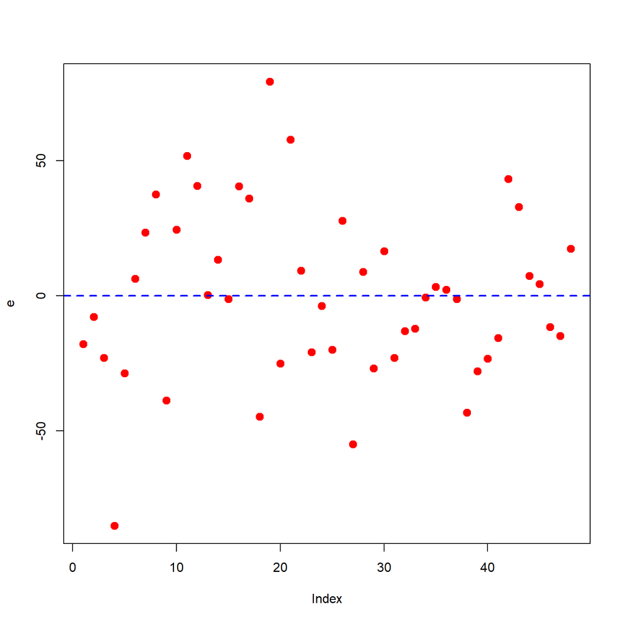

```r
plot(e,cex=2,pch=20,col="red")
abline(h=0,lwd=2,lty=2,col="blue")
```

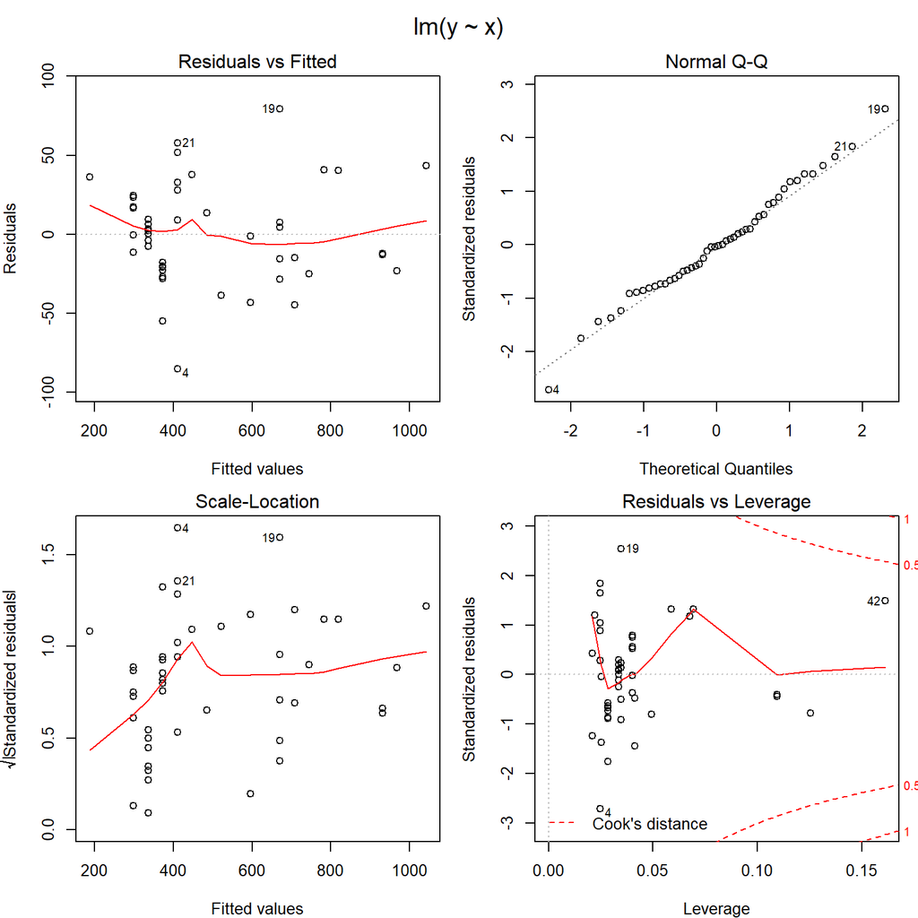

```r
par(mfrow=c(2,2),mar=c(4,4,2,1),oma=c(0,0,2,0))
plot(fit)
```

```r
#Predict fitted line
yhat <-predict(fit)
yhat
```

```
##         1         2         3         4         5         6         7
##  372.9483  335.7381  372.9483  410.1586  670.6303  335.7381  298.5278
##         8         9        10        11        12        13        14
##  447.3688  521.7893  298.5278  410.1586  782.2611  335.7381  484.5791
##        15        16        17        18        19        20        21
##  596.2098  819.4713  186.8971  707.8406  670.6303  745.0508  410.1586
##        22        23        24        25        26        27        28
##  335.7381  372.9483  335.7381  372.9483  410.1586  372.9483  410.1586
##        29        30        31        32        33        34        35
##  372.9483  298.5278  372.9483  931.1020  931.1020  298.5278  335.7381
##        36        37        38        39        40        41        42
##  335.7381  596.2098  596.2098  372.9483  968.3123  670.6303 1042.7328
##        43        44        45        46        47        48
##  410.1586  670.6303  670.6303  298.5278  707.8406  298.5278
```

```r
max(abs(e-(y-yhat)))
```

```
## [1] 9.485746e-13
```

```r
max(abs(e-(y-coef(fit)[1]-coef(fit)[2]*x)))
```

```
## [1] 9.485746e-13
```

```r
#Check sum of residuals
sum(e)
```

```
## [1] -1.865175e-14
```

```r
sum(e*x)
```

```
## [1] 6.959711e-15
```

```r
#Plot the residuals on the vertical axis versus mass on the horizontal axis.
plot(x,e,xlab="Carat(Mass)",ylab="Residuals(SIN$)",col="black",cex=2,pch=20)
abline(h=0,lwd=2,col="red",lty=1)

#Grabbing residual variation
summary(fit)$sigma
```

```
## [1] 31.84052
```

```r
sqrt(sum(resid(fit)^2/(n-2)))
```

```
## [1] 31.84052
```

[figure not shown]

- Heteroskedasticity refers to the circumstances in which the variability of a variable is unequal across the range of values of a second variable that predicts it. for e.g. annual income and age.

## Inference in Regression

- Inference is the process of drawing conclusions about a population using a sample. Hypothesis test and confidence intervals are among the most common forms of statistical inference.

## Getting Confidence Interval

```r
library(HistData)
library(reshape)
library(Hmisc)
library(backports)
library(htmlTable)
library(ggplot2)
library(UsingR)
data(diamond)
y <-diamond$price
x <-diamond$carat
fit <-lm(y~x,data=diamond)
sumCoef <-summary(fit)$coef
sumCoef
```

```
##              Estimate Std. Error   t value     Pr(>|t|)
## (Intercept) -259.6259   17.31886 -14.99094 2.523271e-19
## x           3721.0249   81.78588  45.49715 6.751260e-40
```

```r
#confidence interval
sumCoef[1,1]+c(-1,1)*qt(0.975,df=fit$df)*sumCoef[1,2]
```

```
## [1] -294.4870 -224.7649
```

```r
sumCoef[2,1]+c(-1,1)*qt(0.975,df=fit$df)*sumCoef[2,2]
```

```
## [1] 3556.398 3885.651
```

## Prediction

- Consider predicting Y at a value of X. For e.g. predicting the price of diamond given the carat.
- The obvious estimate for prediction at pt Xo is Bo + B1(Xo).
- A standard error is needed to create a prediction interval.

```r
library(HistData)
library(reshape)
library(Hmisc)
library(backports)
library(htmlTable)
library(ggplot2)
library(UsingR)
data(diamond)
y <-diamond$price
x <-diamond$carat
fit <-lm(y~x,data=diamond)
summary(fit)$coef
```

```
##              Estimate Std. Error   t value     Pr(>|t|)
## (Intercept) -259.6259   17.31886 -14.99094 2.523271e-19
## x           3721.0249   81.78588  45.49715 6.751260e-40
```

```r
#Predict
newx <-c(0.16,0.27,0.34)
#Manual approach
coef(fit)[1]+coef(fit)[2]*newx
```

```
## [1]  335.7381  745.0508 1005.5225
```

```r
#General method
predict(fit,newdata=data.frame(x=newx))
```

```
##         1         2         3
##  335.7381  745.0508 1005.5225
```